# Muestrador de Gibbs

24/9/2018

## ¿Qué es el muestrador de Gibbs?

- Permite muestrar de una distribución sin tener que calcular la densidad.
- Queremos muestrar de f(x)

\[ f(x) = \int \cdots \int f(x, y_1, \cdots, y_p) dy_1 \cdots dy_p \]

- ¿Qué podemos hacer?
- Resolver analítica o numéricamente, pero ¿si no se puede?

## ¿Cómo funciona el muestrador de Gibbs?

- Ilustraremos con un ejemplo bivariado. Queremos muestras de \(f(x)\) (distribuida de manera conjunta con \(y\)). Conocemos las condicionales \(f(x|y)\) y \(f(y|x)\).
- Se especifica un valor inicial para \(Y'_0 = y'_0\).
- Se obtiene apartir de las condicionales una sucesión de muestras para x e y:

\[ X'_j \sim f(x|Y'_j = y'_j) \] \[ Y'_{j+1} \sim f(y|X'_j = x'_j) \]

- Obtenemos así una secuencia: \(Y'_0, X'_0, Y'_1, X'_1,\cdots Y'_k, X'_k,\)
- Resulta que bajo algunas condiciones generales, cuando \(k \rightarrow \infty\), \(X'_k\) es efectivamente una muestra de \(f(x)\)

## Aplicación

### Condicionales exponenciales truncas

\[ \begin{aligned} f(x|y) &= \frac{y e^{-yx}}{1- e^{-By}}, 0 < x < B < \infty \\ f(y|x) &= \frac{x e^{-xy}}{1- e^{-By}}, 0 < y < B < \infty \end{aligned} \]

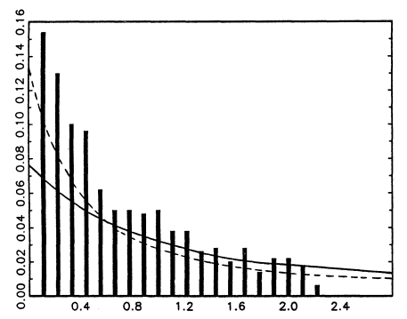

## Prueba simple de la convergencia del muestrador de Gibbs - Caso Discreto

Mostraremos como converge el muestreo tomando como ejemplo una distribución bivariada, donde X e Y se distribuyen Bernoulli de manera conjunta.

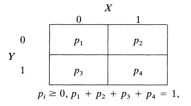

La distribución conjunta de X, Y está dada por:

\[ \begin{bmatrix}f_{x,y}(0,0) & f_{x,y}(1,0)\\ f_{x,y}(0,1) & f_{x,y}(1,1) \end{bmatrix}=\begin{bmatrix}p_{1} & p_{2}\\ p_{\text{3}} & p_{4} \end{bmatrix} \]

La marginal de X es:

\[ f_x = \begin{bmatrix} p_1 + p_3 & p_2 + p_4 \end{bmatrix} \]

Determinamos las probabilidades condicionales \(X|Y = y\) e \(Y|X = x\), formulando las siguientes matrices:

\[ A_{y|x}=\begin{bmatrix} Prob(Y=0|X=0) & Prob(Y=1|X=0)\\ Prob(Y=0|X=1)& Prob(Y=1|X=1) \end{bmatrix} = \begin{bmatrix} \frac{p_1}{p_1+p_3} & \frac{p_3}{p_1+p_3}\\ \frac{p_2}{p_2+p_4}& \frac{p_4}{p_2+p_4} \end{bmatrix} \]

\[ A_{x|y}=\begin{bmatrix} Prob(X=0|Y=0) & Prob(X=1|Y=0)\\ Prob(X=0|Y=1)& Prob(X=1|Y=1) \end{bmatrix} = \begin{bmatrix} \frac{p_1}{p_1+p_2} & \frac{p_2}{p_1+p_2}\\ \frac{p_3}{p_3+p_4}& \frac{p_4}{p_3+p_4} \end{bmatrix} \]

- Queremos muestrar de la marginal de X (\(X'_0, X'_1, X'_2, \cdots\)).
- Para ir de \(X'_0 \rightarrow X'_1\) debemos muestrar \(Y'_1\), es decir, \(X'_0 \rightarrow Y'_1 \rightarrow X'_1\).

\[ P(X'_1 = x_1 |X'_0 = x_0) = \sum_y P(X'_1 = x_1 |Y'_1 = y) \times P(Y'_1 = y |X'_0 = x_0) \]

Para este caso en particular, se tiene que la matrices de transición para x está dada por:

\[A_{x|x} = A_{y|x} A_{x|y}\]

Ahora, es directo calcular la distribución marginal de realización k, \(X'_k\):

\[f_k = f_0 A^k_{x|x} = (f_0 A^{k-1}_{x|x})A_{x|x} = f_{k-1}A_{x|x}\]

Bajo ciertas condiciones, se tiene un punto fijo tal que:

\[ f = f A_{x|x}\]  
En nuestro caso simple:  
\[ \begin{aligned} f_x A_{x|x} &= f_x A_{y|x} A_{x|y} \\ &= \begin{bmatrix} p_1 + p_3 & p_2 + p_4 \end{bmatrix} \begin{bmatrix} \frac{p_1}{p_1+p_3} & \frac{p_3}{p_1+p_3}\\ \frac{p_2}{p_2+p_4}& \frac{p_4}{p_2+p_4} \end{bmatrix} \begin{bmatrix} \frac{p_1}{p_1+p_2} & \frac{p_2}{p_1+p_2}\\ \frac{p_3}{p_3+p_4}& \frac{p_4}{p_3+p_4} \end{bmatrix} \\ &= \begin{bmatrix} p_1 + p_2 & p_3 + p_4 \end{bmatrix} \begin{bmatrix} \frac{p_1}{p_1+p_2} & \frac{p_2}{p_1+p_2}\\ \frac{p_3}{p_3+p_4}& \frac{p_4}{p_3+p_4} \end{bmatrix}\\ &= \begin{bmatrix} p_1 + p_3 & p_2 + p_4 \end{bmatrix} \\ &= f_x \end{aligned} \]

### Ejemplo numérico

Tomemos \(p_1 = 0.1, p_2 = 0.4, p_3 = 0.15\) y \(p_4 = 0.35\). Por tanto:

\[ f_x = \begin{bmatrix} p_1 + p_3 & p_2 + p_4 \end{bmatrix} = \begin{bmatrix} 0.25 & 0.75 \end{bmatrix} \]

## Intuición para el caso bivariado continuo

¿Cómo es que podemos llegar a partir de las condicionales a la marginal?

- Conocemos \(f_{X|Y}(x|y)\) y \(f_{Y|X}(y|x)\). Si queremos la marginal, por definición:

\[ f_X(x) = \int f_{xy}(x,y)dy \]

- Por Bayes sabemos que: \(f_{xy}(x,y) = f_{X|Y}(x|y)f_Y(y)\), por tanto:

\[ f_X(x) = \int f_{X|Y}(x|y)f_Y(y)dy \] De manera similar, tenemos \(f_{xy}(x,y) = f_{Y|X}(y|x)f_X(y)\) con:

\[f_Y(y) = \int f_{Y|X}(y|x)f_X(x)dx\]

Reemplazando:

\[ \begin{aligned} f_X(x) &= \int f_{X|Y}(x|y)\int f_{Y|X}(y|t)f_X(t)dtdy \\ &= \int \left [ \int f_{X|Y}(x|y) f_{Y|X}(y|t) dy \right ]f_X(t)dt \\ &= \int h(x,t)f_X(t)dt \end{aligned} \]

con \(h(x,t) = \left [ \int f_{X|Y}(x|y) f_{Y|X}(y|t) dy \right ]\).

- Llegamos a lo que se conoce como una ecuación de punto fijo integral.
- La secuencia de Gibbs es una manera de converger a la solución de la ecuación.

**¿Gibbs siempre converge a la solución?**

Veamos el primer ejemplo, pero sin acotar las distribuciones condicionales.

\[ f(x|y) = y e^{-yx}, 0 < x < \infty \\ f(y|x) = x e^{-xy}, 0 < y < \infty \] \[ \begin{aligned} f_{X}(x) &= \int_0^\infty \left [\int_0^\infty y e^{-yx}t e^{-ty}dy \right]f_X(t)dt \\ &= \int_0^\infty \left [\frac{t}{(x+t)^2} \right]f_X(t)dt \end{aligned} \]

Y notamos que \(f_X(t) = 1/t\) es solución puesto que:

\[ \begin{aligned} \frac{1}{x} &= \int_0^\infty \left [\frac{t}{(x+t)^2} \right]\frac{1}{t}dt \\ &= \int_0^\infty \left [\frac{1}{(x+t)^2} \right]dt \\ &= \left [\frac{-1}{(x+t)} \right]_{t=0}^{t=\infty} \\ &= 0 - \frac{-1}{x} = \frac{1}{x}\\ \end{aligned} \]

Pero cuando intentamos aplicar el muestrador de Gibbs a estas condicionales, no obtenemos convergencia:

[figure not shown]

- Ahora el procedimiento de Gibbs no converge (no obtenemos una aproximación de \(1/x\)).
- Podemos evitar esto si truncamos las distribuciones condicionales de manera que se cumpla:

\[ \int_0^B f_X(x)dx < \infty \]

- La marginal ya no integra a un número finito:

\[\int_0^\infty \frac{1}{x}dx \rightarrow \infty\]

### Conclusión

Una condición para que algoritmo converga es que la marginal sea una función de densidad \(\int f_X(x)dx < \infty\). Una manera de segurar esto es acotando las condicionales.

**Muchas Gracias!**